# Preliminary random forest results

Brad Compton

2025-04-24

## Initial results

These results are brand-new: I did my first random forest model run on April 23. I’ve only run a small handful of models for one site, Old Town Hill. Here are some results of a representative run. I’m surprised at how well they’re fitting–correct classification rates are in the mid-90s, which is superb for a start.

```
Confusion Matrix and Statistics

          Reference
Prediction  1  2  3  4  5  6  7  8  9 10 11 12 13 21 22 23 25 26 33
        1  82  4  0  0  0  0  0  0  0  1  1  0  1  1  0  0  0  0  0
        2   3 66  0  1  2  1  1  2  0  0  0  0  3  0  0  1  0  2  0
        3   0  0 84  2  1  0  0  0  0  0  0  0  0  0  0  0  0  0  0
        4   0  2  3 79  2  0  0  0  0  1  1  0  2  0  0  0  0  0  0
        5   0  3  1  6 73  2  0  1  0  0  0  0  0  0  0  0  0  0  0
        6   0  4  0  1  2 67  0  0  0  6  0  0  4  0  0  1  0  6  0
        7   0  0  0  0  0  0 25  0  0  0  0  0  0  0  0  0  0  0  0
        8   0  0  0  0  0  0  0 92  0  0  0  0  0  0  0  0  0  0  0
        9   0  2  0  0  3  1  0  0 87  0  1  0  0  0  0  0  0  0  0
        10  0  0  0  0  0  0  0  0  0 67  0  0  0  0  0  0  1  0  0
        11  0  0  0  0  0  0  0  0  0  0 84  0  0  0  0  0  0  0  0
        12  0  0  0  0  0  0  0  0  0  0  0 63  0  0  0  0  0  0  0
        13  0  0  0  0  0  0  0  0  0  0  0  0 83  5  0  1  0  0  0
        21  2  0  0  0  0  0  0  0  0  0  0  0  1 79  0  0  0  0  0
        22  0  0  0  0  0  1  0  0  0  0  0  0  0  0 44  0  0  0  0
        23  0  0  0  0  0  0  0  0  0  0  0  0  0  0  0 90  0  0  0
        25  0  0  0  0  1  0  0  0  0  0  0  0  0  0  0  0 83  0  0
        26  0  0  0  0  0  1  0  0  0  0  0  0  0  0  0  0  0 97  0
        33  0  0  0  0  0  0  0  0  0  0  0  0  0  0  0  0  0  0 31

Overall Statistics

               Accuracy : 0.9354
                 95% CI : (0.9216, 0.9474)
    No Information Rate : 0.0714
    P-Value [Acc > NIR] : < 2.2e-16

                  Kappa : 0.9316

 Mcnemar's Test P-Value : NA

Statistics by Class:

                     Class: 1 Class: 2 Class: 3 Class: 4 Class: 5 Class: 6
Sensitivity           0.94253  0.81481  0.95455  0.88764  0.86905  0.91781
Specificity           0.99422  0.98849  0.99783  0.99204  0.99063  0.98283
```

[output cut: 18 more lines]

```
Pos Pred Value         0.93258   0.96341   0.97778   1.00000   0.98810
Neg Pred Value         0.99204   0.99568   1.00000   0.99783   0.99928
Prevalence             0.06390   0.05778   0.02991   0.06322   0.05710
Detection Rate         0.05642   0.05370   0.02991   0.06118   0.05642
Detection Prevalence   0.06050   0.05574   0.03059   0.06118   0.05710
Balanced Accuracy      0.93931   0.96362   0.99965   0.98387   0.99369
                     Class: 26 Class: 33
Sensitivity            0.92381   1.00000
Specificity            0.99927   1.00000
Pos Pred Value         0.98980   1.00000
Neg Pred Value         0.99417   1.00000
Prevalence             0.07138   0.02107
Detection Rate         0.06594   0.02107
Detection Prevalence   0.06662   0.02107
Balanced Accuracy      0.96154   1.00000
```

## Variable importance

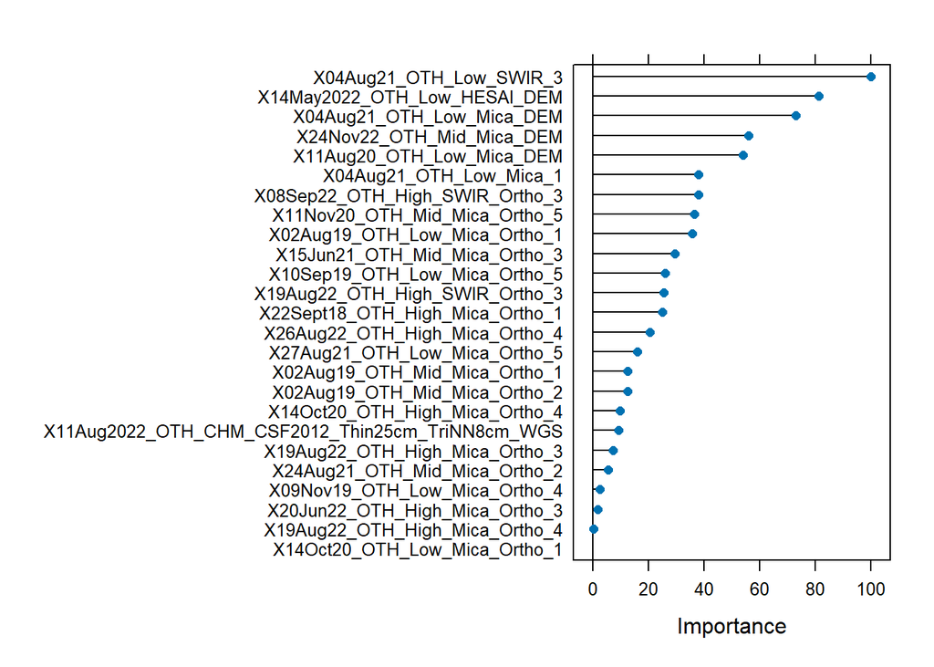

## Comments and caveats

1. These results are super-preliminary. I expect model fits will generally improve as I refine models.
2. These models are based on only 20% of the field points (mostly because I wanted fitting to run fast during development).
3. I built the models on 80% of the selected data points (so 80% of 20% of all pixels in field transects), and held out 20% of points for validation. All stats are based on the holdout validation set.
4. I haven’t tackled spatial autocorrelation yet. I’m concerned that autocorrelation could be contaminating the holdout sets. This may not be a thing, but I want to be sure.
5. I’ve done some minimal tuning of hyperparmeters, but will do more.
6. Field-based transects are not representative, as several classes were photointerpreted in the lab to get sample sizes up. I’m currently balancing representation, as we don’t have true representation. I want to either drop PI-based data and use field-based representation or, better, weight cases by field-based representation.
7. I’m currently ignoring the years field transects and UAS imagery were collected. Will probably want to put some effort into matching them up better (or at least let the data tell us if they matter).

## Next steps

1. Add derived variables such as NDVI, NWDI, NDRE.
2. Try upscaling varaibles by taking focal mean, SD, IQR, maybe 10th and 90th percentile.
3. Assess spatial autocorrelation and decide how sparsely we need to sample the data. Run with more complete datasets if that’s the thing to do.
4. Try targeting subsets of classes and then spit these in subsequent models to see if that improves fits.
5. Try alternatives to random forest. I’m currently thinking of trying AdaBoost, but there are other options. I’m using the `caret` framework, which makes it easy to switch modeling approaches, and there are hundreds of choices.
6. Write the model launching and tracking framework I’ve envisioned, which will make it easy to launch models in parallel as batch processes on Unity, and track model results over time. This will make it possible to run many different models and do preliminary evaluation without producing maps of results. It’ll then be straightforward to produce maps of promising models.
7. Make data sampling more flexible.
8. Implement a macro naming system for variables so we can use common names across sites (e.g., `21Aug20_OTH_MidOut_SWIR_Ortho` from Old Town Hill and `17Sep22_RED_Mid_SWIR_Ortho` from Red River could both be referred to as `Late_Mid_SWID_Ortho`.
9. Produce models for other sites as Ryan finishes preparing transect data. Peggoty, Red River, Wellfleet, and Westport should be ready soon.